# Probability Sampling Results NLA 2017

Alene Onion and Tony Olsen of USEPA (modified by Sabrina Xie)

Last compiled 08 February, 2022, 15:36:20

```r
options(knitr.duplicate.label = 'allow')
```

Doing the probability sampling results analysis with NLA data of lakes in Northern Appalachians with area >6.5 acres

## Prepping data

Merging relevant raw data files and filtering

```r
################################################################################################################
#reading in and formatting raw data
################################################################################################################

library(tidyverse)
library(huxtable)
library(ggplot2)
library(lubridate)

# read in NLA data
setwd("~/OneDrive - New York State Office of Information Technology Services/Rscripts/Probability.Sampling/")

chem <- read.csv("nla_2017_water_chemistry_chla-data.csv")

chem <- chem %>%
  filter(ANALYTE %in% c("NTL","CHLA","PTL","NITRATE_N","COLOR","CHLORIDE"),
         NARS_FLAG == "") %>%
  select(UID,SITE_ID,DATE_COL,ANALYTE,RESULT) %>%
  pivot_wider(names_from= ANALYTE ,values_from = RESULT,) %>%
  rename(TN=NTL,TP=PTL)

oxygen <- read.csv("nla_2017_profile-data.csv")

oxygen <- oxygen %>%
  select(UID,SITE_ID,DATE_COL,DEPTH,OXYGEN) %>%
  # dissolved oxygen:
  # keep DO values between 0 and 2m depth
  mutate(keep=case_when(
    DEPTH <= 2 ~ "yes",
    DEPTH > 2 ~ "no")) %>%
  filter(keep=="yes") %>%
  select(-keep)

# mean DO for each lake
DO <- aggregate(oxygen$OXYGEN,list(oxygen$SITE_ID,oxygen$DATE_COL),FUN=mean)
# add back in
oxygen <- merge(oxygen,DO,by.x=c("SITE_ID","DATE_COL"),by.y=c("Group.1","Group.2"),all.x=TRUE)
oxygen$x <- as.numeric(oxygen$x)
oxygen <- oxygen %>%
  select(-c(DEPTH,OXYGEN)) %>%
  rename(OXYGEN=x) %>%
  distinct()

sites <- read.csv("nla_2017_site_information-data.csv")

sites <- sites %>%
  mutate(include=case_when(
    AG_ECO9=="NAP" & AREA_HA>2.63 ~ "yes",
    SITE_ID=TRUE ~ "no"
  )) %>%
  select(UID,SITE_ID,AREA_CAT6,EVAL_CAT,YCOORD,XCOORD,WGT_TP_EXTENT,include) %>%
  filter(WGT_TP_EXTENT != 0)

att <- merge(chem,oxygen,by=c("UID","SITE_ID","DATE_COL"),all.y=TRUE,all.x=TRUE)
att <- merge(att,sites,by=c("UID","SITE_ID"))
att$CHLA <- as.numeric(att$CHLA)
att$TN <- as.numeric(att$TN)
att$TP <- as.numeric(att$TP)
att$CHLORIDE <- as.numeric(att$CHLORIDE)
att$OXYGEN <- as.numeric(att$OXYGEN)
att$COLOR <- as.numeric(att$COLOR)
att$DINTP <- as.numeric(att$NITRATE_N)/(as.numeric(att$TP)/1000)

# selecting parameters and adding trophic status

att<-att %>%
  # trophic status
  mutate(phos_trophic=case_when(
    TP<=10 ~ "oligotrophic",
    between(TP,10,20) ~ "mesotrophic",
    TP>=20 ~ "eutrophic")) %>%
  mutate(chla_trophic=case_when(
    CHLA<=2 ~ "oligotrophic",
    between(CHLA,2,8) ~ "mesotrophic",
    CHLA>=8 ~ "eutrophic")) %>%
  # EPA thresholds
  mutate(TP_threshold=case_when(
    TP<=16 ~ "Good",
    between(TP, 16, 27.9) ~ "Fair",
    TP>=27.9 ~ "Poor")) %>%
  mutate(TN_threshold=case_when(
    TN<=0.428 ~ "Good",
    between(TN, 0.428, 0.655) ~ "Fair",
    TN>=0.655 ~ "Poor")) %>%
  mutate(CHLA_threshold=case_when(
    CHLA<=4.52 ~ "Good",
    between(CHLA, 4.52, 8.43) ~ "Fair",
    CHLA>=8.43 ~ "Poor")) %>%
  # dissolved oxygen
  mutate(d.oxygen=case_when(
    OXYGEN<=3 ~ "Poor",
    between(OXYGEN, 3, 5) ~ "Fair",
    OXYGEN>=5 ~ "Good")) %>%
  #leech
  mutate(leech=case_when(
    TP<=30 & COLOR<=20 ~ "Blue",
    TP>30 & COLOR<=20 ~ "Green",
    TP<=30 & COLOR>20 ~ "Brown",
    TP>30 & COLOR>20 ~ "Murky"
  )) %>%
  #chloride
  mutate(chloride=case_when(
    CHLORIDE <= 35 ~ "Low",
    between(CHLORIDE,35,250) ~ "Medium",
    CHLORIDE >= 250 ~ "High"))

framesize_LC <- c("EPA"=5721)
```

## Comparison to NYS thresholds

PLEAE NOTE: this presumes that the lakes we didn’t sample were random. A reasonable assumption but it’s obviously preferable to sample all the lakes in the list to avoid this uncertainty.

```r
library(spsurvey)

# Size classes
SizeExtent <- cat_analysis(
  dframe=att,
  vars=c("AREA_CAT6"),
  subpops = "include",
  siteID = "SITE_ID",
  weight = "WGT_TP_EXTENT",
  xcoord = "XCOORD",
  ycoord = "YCOORD")
```

During execution of the program, a warning message was generated. The warning message is stored in a data frame named ‘warn_df’. Enter the following command to view the warning message: warnprnt()

```r
table <- SizeExtent %>% filter(Subpopulation=="yes") %>% select(Category,nResp,Estimate.U,LCB95Pct.U,UCB95Pct.U)
hux <- as_hux(table)
number_format(hux) <- 2
theme_plain(hux)
```

| Category | nResp | Estimate.U | LCB95.00Pct.U | UCB95.00Pct.U |
| --- | --- | --- | --- | --- |
| (1.00,4.00] | 6.00 | 1870.35 | 366.46 | 3374.24 |
| (10.00,20.00] | 21.00 | 1791.06 | 981.11 | 2601.02 |
| (20.00,50.00] | 24.00 | 1695.39 | 996.11 | 2394.68 |
| (4.00,10.00] | 16.00 | 2379.82 | 1449.22 | 3310.41 |
| >50.00 | 33.00 | 1990.71 | 1303.48 | 2677.94 |
| Total | 100.00 | 9727.33 | 8056.90 | 11397.76 |

```r
# Trophic classes
# Estimate assessment result
CatExtent2 <- cat_analysis(
  dframe=att,
  vars=c("chla_trophic","phos_trophic"),
  subpops = "include",
  siteID = "SITE_ID",
  weight = "WGT_TP_EXTENT",
  xcoord = "XCOORD",
  ycoord = "YCOORD")
```

During execution of the program, a warning message was generated. The warning message is stored in a data frame named ‘warn_df’. Enter the following command to view the warning message: warnprnt()

```r
forplot2<-CatExtent2 %>%
  mutate(pct=Estimate.P,
         pct_lcb=LCB95Pct.P,
         pct_ucb=UCB95Pct.P) %>%
  filter(Category!="Total",
         Subpopulation=="yes") %>%
  select(Indicator,Category,pct,pct_lcb,pct_ucb) %>%
  distinct() %>%
  gather(percent,results,-Indicator,-Category) %>%
  mutate(Indicator=ifelse(Indicator=="chla_trophic","Trophic Status from ChlA",Indicator),
         Indicator=ifelse(Indicator=="phos_trophic","Trophic Status from Phosphorus",Indicator))

table <- forplot2 %>%
  spread(percent,results)  %>%
  rename(Percentage=pct,Lower95Confidence=pct_lcb,Upper95Confidence=pct_ucb)

hux <- as_hux(table)
number_format(hux) <- 2
theme_plain(hux)
```

| Indicator | Category | Percentage | Lower95.00Confidence | Upper95.00Confidence |
| --- | --- | --- | --- | --- |
| Trophic Status from ChlA | eutrophic | 19.90 | 12.12 | 27.68 |
| Trophic Status from ChlA | mesotrophic | 63.55 | 51.60 | 75.51 |
| Trophic Status from ChlA | oligotrophic | 16.55 | 6.83 | 26.26 |
| Trophic Status from Phosphorus | eutrophic | 22.80 | 14.16 | 31.44 |
| Trophic Status from Phosphorus | mesotrophic | 41.95 | 29.71 | 54.18 |
| Trophic Status from Phosphorus | oligotrophic | 35.26 | 23.44 | 47.07 |

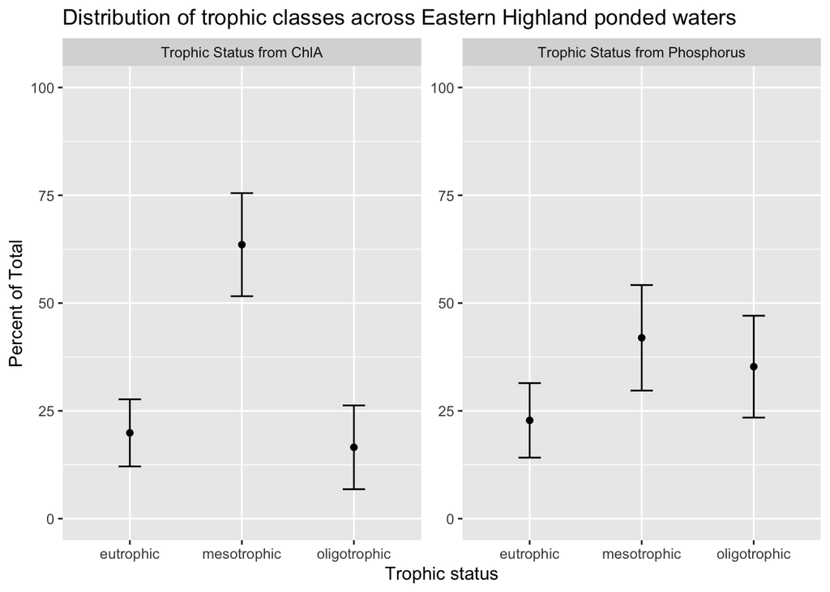

```r
forplot2$Category <- factor(forplot2$Category, levels=c("oligotrophic", "mesotrophic", "eutrophic"))

ggplot(table,aes(x=Category,y=Percentage)) +
  geom_point()+
  geom_errorbar(aes(ymin=Lower95Confidence,ymax=Upper95Confidence),width=0.2)+
  theme(legend.position = "none")+
  facet_wrap(~Indicator,scales = "free_y")+
  ylim(0,100)+
  labs(title="Distribution of trophic classes across Eastern Highland ponded waters",y="Percent of Total",x="Trophic status")
```

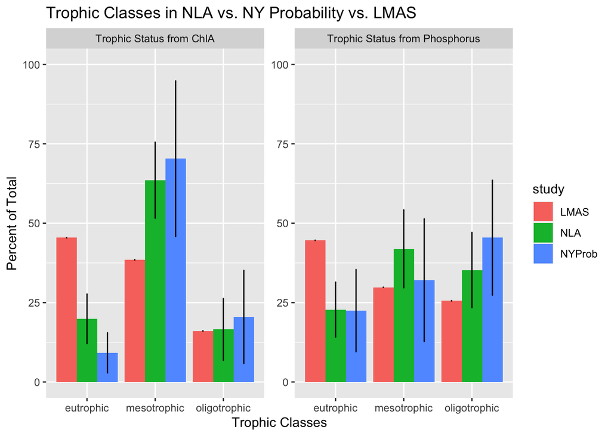

```r
forplot5<-forplot2 %>%
  spread(percent,results) %>%
  rename(percent=pct) %>%
  mutate(study="NLA") %>%
  add_row(Indicator="Trophic Status from ChlA", #lmas
          Category="eutrophic",
          study="LMAS",
          percent=((215/473)*100)) %>%
  add_row(Indicator="Trophic Status from ChlA",
          Category="mesotrophic",
          study="LMAS",
          percent=((182/473)*100)) %>%
  add_row(Indicator="Trophic Status from ChlA",
          Category="oligotrophic",
          study="LMAS",
          percent=((76/473)*100)) %>%
  add_row(Indicator="Trophic Status from Phosphorus",
          Category="eutrophic",
          study="LMAS",
          percent=((211/473)*100)) %>%
  add_row(Indicator="Trophic Status from Phosphorus",
          Category="mesotrophic",
          study="LMAS",
          percent=((141/473)*100)) %>%
  add_row(Indicator="Trophic Status from Phosphorus",
          Category="oligotrophic",
          study="LMAS",
          percent=((121/473)*100)) %>%
  add_row(Indicator="Trophic Status from ChlA", #ny prob
          Category="eutrophic",
          study="NYProb",
          percent=9.18,
          pct_lcb=2.88,
          pct_ucb=15.48) %>%
  add_row(Indicator="Trophic Status from ChlA",
          Category="mesotrophic",
          study="NYProb",
          percent=70.32,
          pct_lcb=45.82,
          pct_ucb=94.82) %>%
  add_row(Indicator="Trophic Status from ChlA",
          Category="oligotrophic",
          study="NYProb",
          percent=20.50,
          pct_lcb=5.86,
          pct_ucb=35.13) %>%
  add_row(Indicator="Trophic Status from Phosphorus",
          Category="eutrophic",
          study="NYProb",
          percent=22.48,
          pct_lcb=9.56,
          pct_ucb=35.40)  %>%
  add_row(Indicator="Trophic Status from Phosphorus",
          Category="mesotrophic",
          study="NYProb",
          percent=32.08,
          pct_lcb=12.77,
          pct_ucb=51.38) %>%
  add_row(Indicator="Trophic Status from Phosphorus",
          Category="oligotrophic",
          study="NYProb",
          percent=45.44,
          pct_lcb=27.37,
          pct_ucb=63.52) %>%
  mutate(pct_lcb=ifelse(is.na(pct_lcb),percent,pct_lcb),
         pct_ucb=ifelse(is.na(pct_ucb),percent,pct_ucb))


ggplot(forplot5, aes(x=Category,fill=study)) +
  geom_bar(aes(y=percent),stat = "identity", position = position_dodge())+
  geom_errorbar(aes(ymin=pct_lcb, ymax=pct_ucb), width=.05,
                 position=position_dodge(.9))+
  facet_wrap(~Indicator,scales = "free_y")+
  ylim(0,100)+
  labs(title="Trophic Classes in NLA vs. NY Probability vs. LMAS",y="Percent of Total",x="Trophic Classes")
```

```r
##### CHLORIDE #####
CatExtent <- cat_analysis(
  dframe=att,
  vars=c("chloride"),
  subpops = "include",
  siteID = "SITE_ID",
  weight = "WGT_TP_EXTENT",
  xcoord = "XCOORD",
  ycoord = "YCOORD")
```

During execution of the program, a warning message was generated. The warning message is stored in a data frame named ‘warn_df’. Enter the following command to view the warning message: warnprnt()

```r
forplot<-CatExtent %>%
  mutate(pct=Estimate.P,
         pct_lcb=LCB95Pct.P,
         pct_ucb=UCB95Pct.P) %>%
  filter(Category!="Total",Subpopulation=="yes") %>%
  select(Indicator,Category,pct,pct_lcb,pct_ucb) %>%
  distinct() %>%
  gather(percent,results,-Indicator,-Category)

table <- forplot %>%
  spread(percent,results)  %>%
  rename(Percentage=pct,Lower95Confidence=pct_lcb,Upper95Confidence=pct_ucb)

hux <- as_hux(table)
number_format(hux) <- 2
theme_plain(hux)
```

| Indicator | Category | Percentage | Lower95.00Confidence | Upper95.00Confidence |
| --- | --- | --- | --- | --- |
| chloride | High | 0.00 | 0.00 | 0.00 |
| chloride | Low | 91.32 | 85.37 | 97.26 |
| chloride | Medium | 8.68 | 2.74 | 14.63 |

## Comparison to NLA thresholds

The following code performs the analysis against EPA’s condition thresholds as used in the National Lakes Assessments. It uses the number of sampled lakes in each condition category (for total phosphorus, total nitrogen and chlorophyll) to estimate the ratio of all lakes in good, fair and poor condition.

```r
# EPA nutrient threshold
#  Estimate assessment result
CatExtent <- cat_analysis(
  dframe=att,
  vars=c("TP_threshold","CHLA_threshold","TN_threshold"),
  subpops = "include",
  siteID = "SITE_ID",
  weight = "WGT_TP_EXTENT",
  xcoord = "XCOORD",
  ycoord = "YCOORD")
```

During execution of the program, a warning message was generated. The warning message is stored in a data frame named ‘warn_df’. Enter the following command to view the warning message: warnprnt()

```r
forplot<-CatExtent %>%
  mutate(pct=Estimate.P,
         pct_lcb=LCB95Pct.P,
         pct_ucb=UCB95Pct.P) %>%
  filter(Category!="Total",Subpopulation=="yes") %>%
  select(Indicator,Category,pct,pct_lcb,pct_ucb) %>%
  distinct() %>%
  gather(percent,results,-Indicator,-Category) %>%
  mutate(Indicator=ifelse(Indicator=="CHLA_threshold","ChlA",Indicator),
         Indicator=ifelse(Indicator=="TP_threshold","Phosphorus",Indicator),
         Indicator=ifelse(Indicator=="TN_threshold","Total Nitrogen",Indicator))

table <- forplot %>%
  spread(percent,results)  %>%
  rename(Percentage=pct,Lower95Confidence=pct_lcb,Upper95Confidence=pct_ucb)

hux <- as_hux(table)
number_format(hux) <- 2
theme_plain(hux)
```

| Indicator | Category | Percentage | Lower95.00Confidence | Upper95.00Confidence |
| --- | --- | --- | --- | --- |
| ChlA | Fair | 7.96 | 3.68 | 12.23 |
| ChlA | Good | 73.22 | 64.45 | 81.99 |
| ChlA | Poor | 18.82 | 11.26 | 26.38 |
| Phosphorus | Fair | 20.81 | 12.76 | 28.85 |
| Phosphorus | Good | 64.20 | 53.89 | 74.51 |
| Phosphorus | Poor | 15.00 | 8.25 | 21.74 |
| Total Nitrogen | Fair | 25.15 | 13.57 | 36.73 |
| Total Nitrogen | Good | 66.41 | 55.32 | 77.50 |
| Total Nitrogen | Poor | 8.44 | 4.23 | 12.65 |

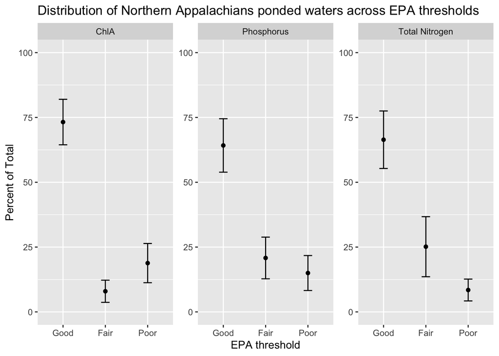

```r
table$Category <- factor(table$Category, levels=c("Good", "Fair", "Poor"))

ggplot(table,aes(x=Category,y=Percentage)) +
  geom_point()+
  geom_errorbar(aes(ymin=Lower95Confidence,ymax=Upper95Confidence),width=0.2)+
  theme(legend.position = "none")+
  facet_wrap(~Indicator,scales = "free_y")+
  ylim(0,100)+
  labs(title="Distribution of Northern Appalachians ponded waters across EPA thresholds",y="Percent of Total",x="EPA threshold")
```

```r
# Dissolved oxygen
#  Estimate assessment result
DOextent <- cat_analysis(
  dframe=att,
  vars=c("d.oxygen"),
  subpops = "include",
  siteID = "SITE_ID",
  weight = "WGT_TP_EXTENT",
  xcoord = "XCOORD",
  ycoord = "YCOORD")
```

During execution of the program, a warning message was generated. The warning message is stored in a data frame named ‘warn_df’. Enter the following command to view the warning message: warnprnt()

```r
#quickly calculate the percentages
totals<-DOextent %>%
  select(Indicator,Category,Estimate.U) %>%
  rename(total=Estimate.U)
totals$total <- DOextent$Estimate.U[4]
DOextent<-merge(DOextent,totals,by=c('Indicator','Category'),all.x = TRUE)

forplot4<-DOextent %>%
  mutate(pct=Estimate.P,
         pct_lcb=LCB95Pct.P,
         pct_ucb=UCB95Pct.P) %>%
  filter(Subpopulation=="yes",Category!="Total") %>%
  select(Indicator,Category,pct,pct_lcb,pct_ucb) %>%
  distinct() %>%
  gather(percent,results,-Indicator,-Category) %>%
  mutate(Indicator=ifelse(Indicator=="d.oxygen","Dissolved Oxygen",Indicator))

table <- forplot4 %>%
  spread(percent,results)  %>%
  rename(Percentage=pct,Lower95Confidence=pct_lcb,Upper95Confidence=pct_ucb)

hux <- as_hux(table)
number_format(hux) <- 2
theme_plain(hux)
```

| Indicator | Category | Percentage | Lower95.00Confidence | Upper95.00Confidence |
| --- | --- | --- | --- | --- |
| Dissolved Oxygen | Fair | 5.36 | 0.85 | 9.87 |
| Dissolved Oxygen | Good | 92.11 | 87.00 | 97.21 |
| Dissolved Oxygen | Poor | 2.53 | 0.08 | 4.98 |

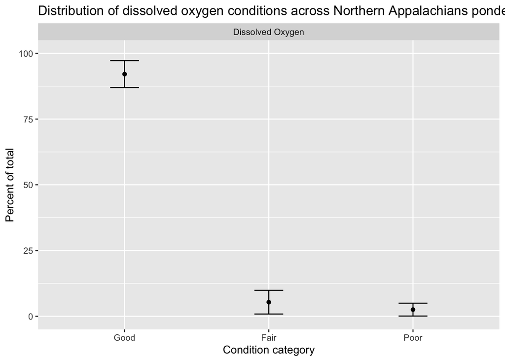

```r
table$Category <- factor(table$Category, levels=c("Good","Fair","Poor"))

ggplot(table,aes(x=Category,y=Percentage)) +
  geom_point()+
  geom_errorbar(aes(ymin=Lower95Confidence,ymax=Upper95Confidence),width=0.2)+
  theme(legend.position = "none")+
  facet_wrap(~Indicator,scales = "free_y")+
  ylim(0,100)+
  labs(title="Distribution of dissolved oxygen conditions across Northern Appalachians ponded waters",y="Percent of total",x="Condition category")
```

## Comparison to NY probability and LMAS

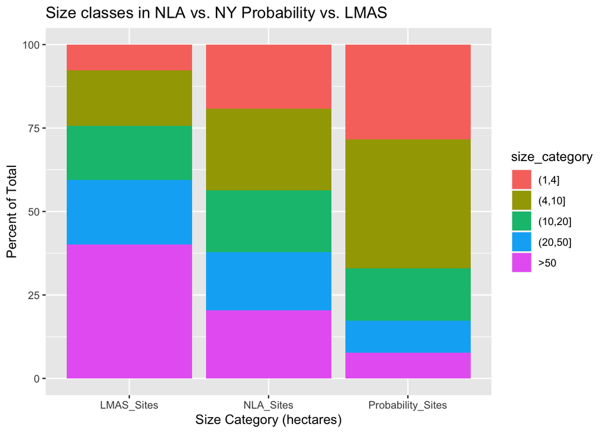

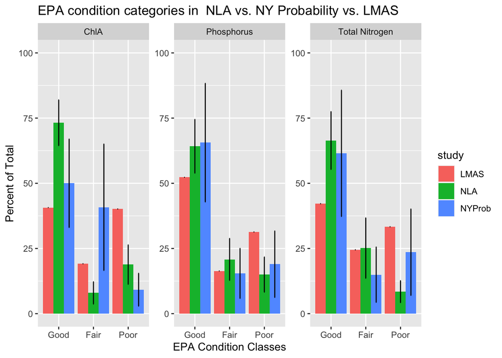

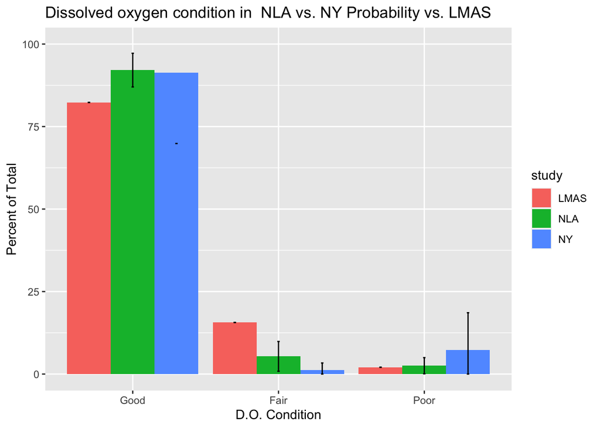

## Leech nutrient-color

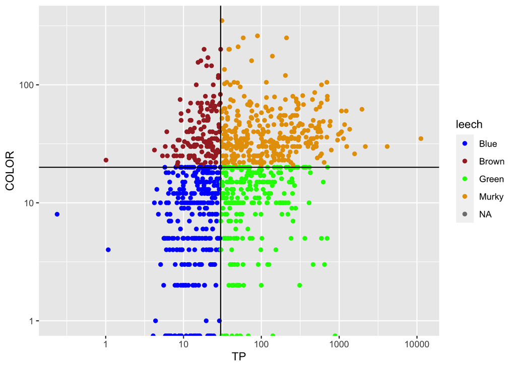

During execution of the program, a warning message was generated. The warning message is stored in a data frame named ‘warn_df’. Enter the following command to view the warning message: warnprnt()

| Indicator | Category | Percentage | Lower95.00Confidence | Upper95.00Confidence |
| --- | --- | --- | --- | --- |
| Lake nutrient-color status | Blue | 45.15 | 33.41 | 56.90 |
| Lake nutrient-color status | Brown | 46.93 | 35.32 | 58.54 |
| Lake nutrient-color status | Green | 1.95 | 0.76 | 3.15 |
| Lake nutrient-color status | Murky | 5.96 | 2.37 | 9.56 |

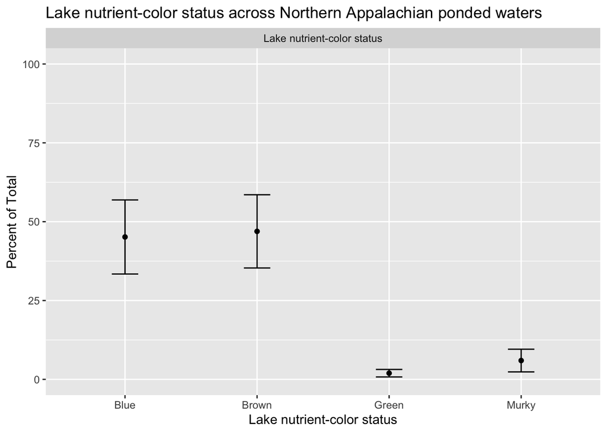

## Sites map

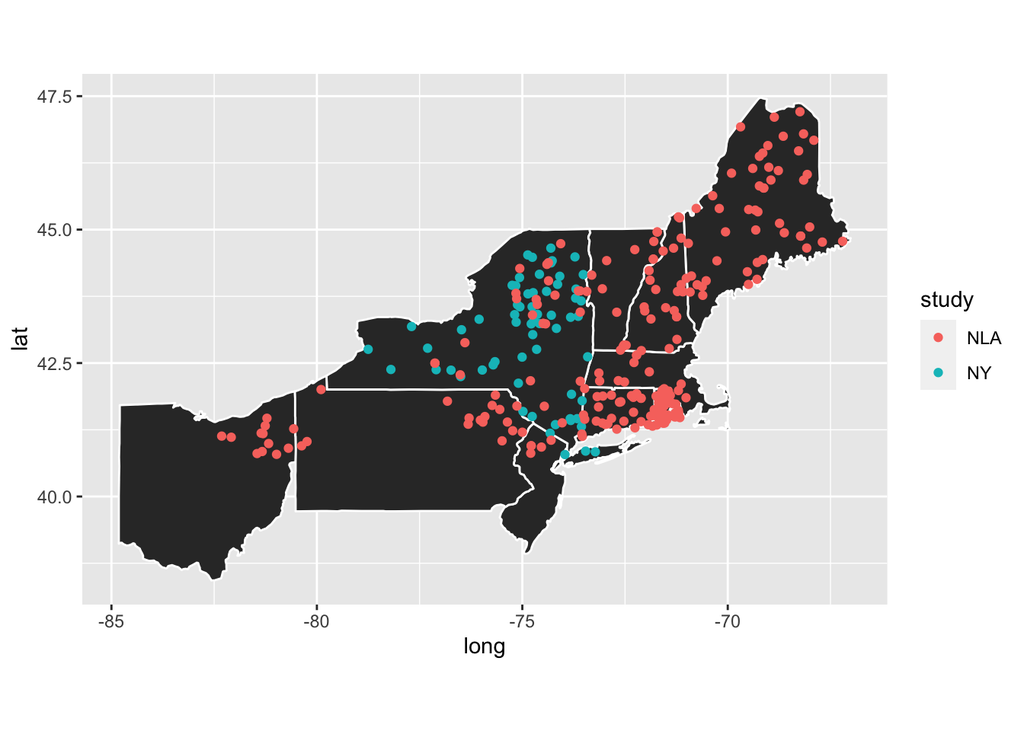

## Questions

- Why are population sizes across size categories the same?
- Why are our error bars bigger than theirs?
- Should the weight adjustment be calculated using the whole population or the filtered subset?